# Report: act_report

# Meet Stephan

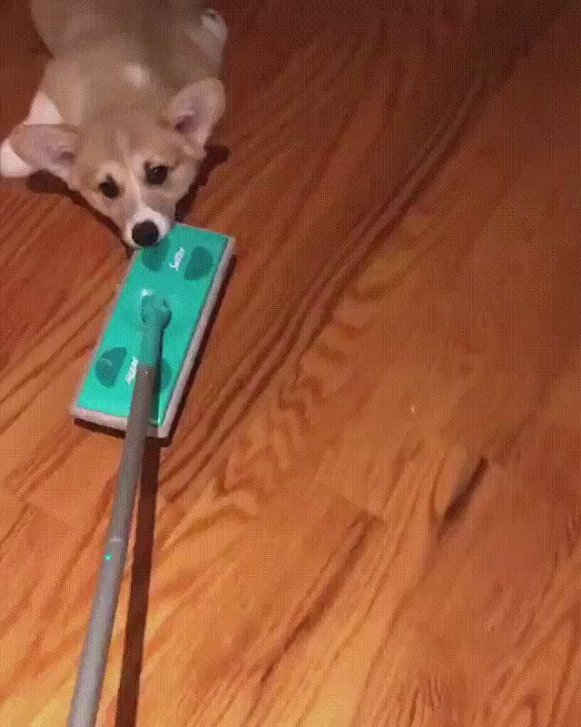

### According to the data provided, it appears that the dog with the most likes (113950 likes) called Stephan

## Another interesting thing is the question,What is the top breeds that gets the most like?

# #1 Chihuahua

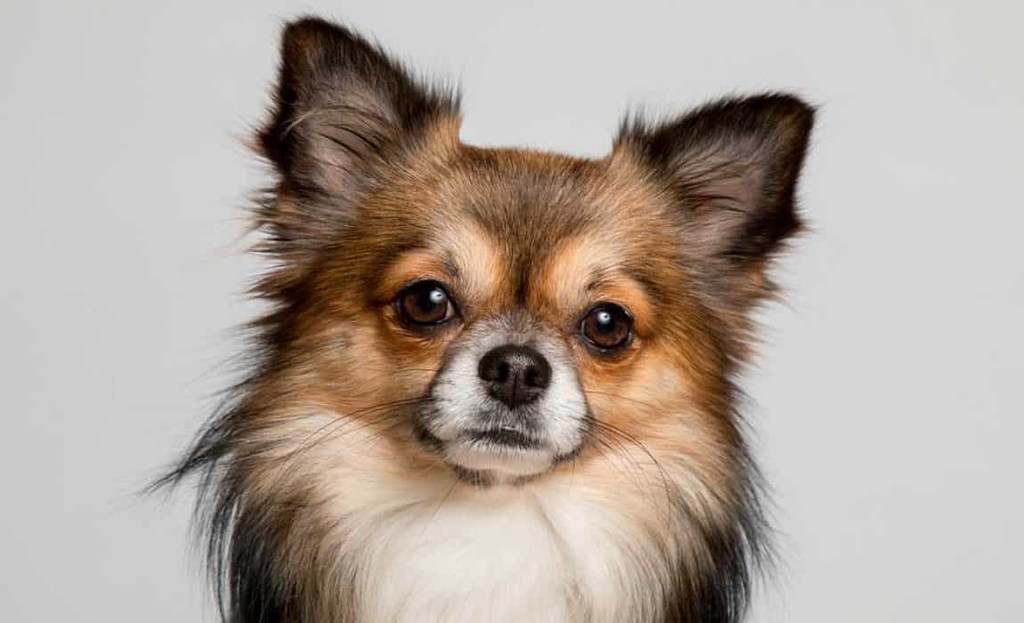

# #2 golden retriever

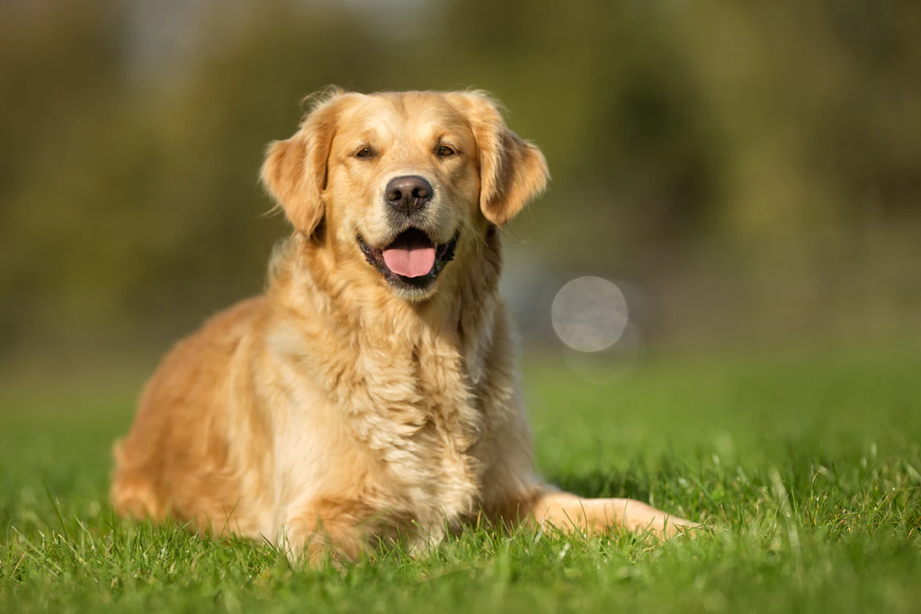

# #3 French bulldog

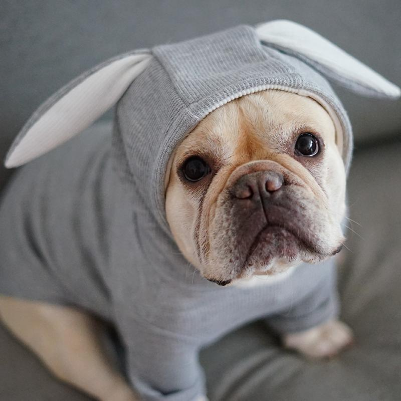

# #4 English springer

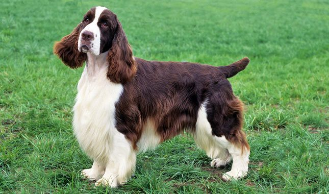

# #5 standard poodle

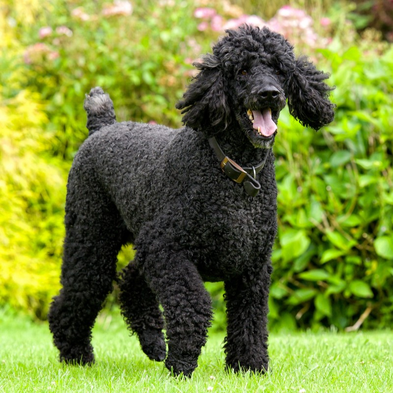

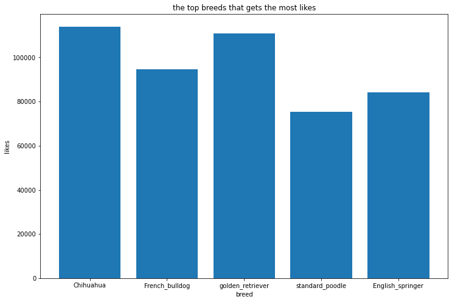

### In the figure above we can find that Chihuahua and golden retriever have the most favorites(likes) respectively

## One more interesting thing is the question,What is the top breeds that gets the most retweets?

# #1 Chihuahua

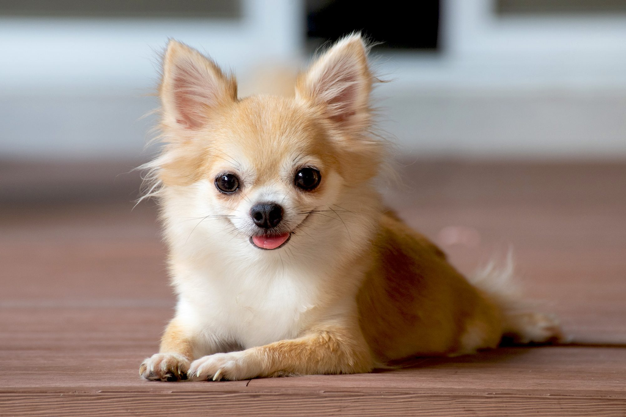

# #2 French bulldog

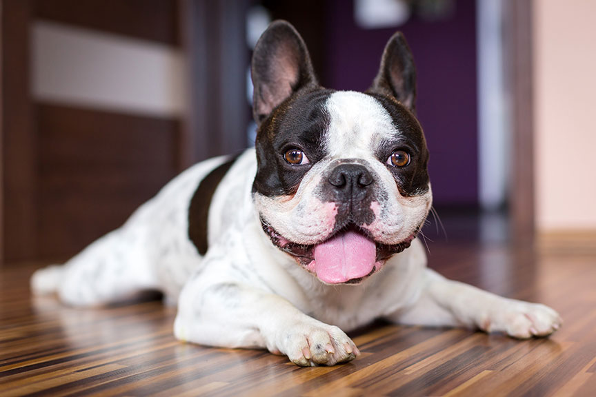

# #3 English springer

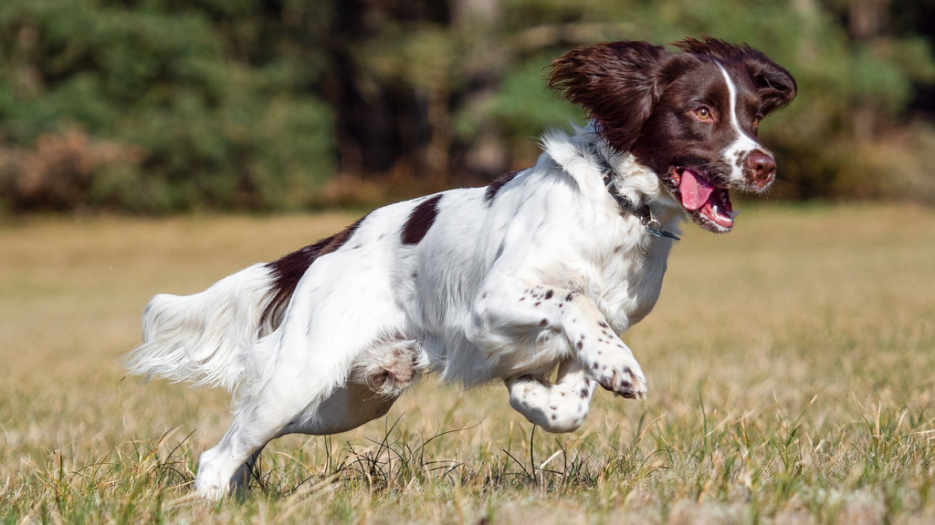

# #4 golden retriever

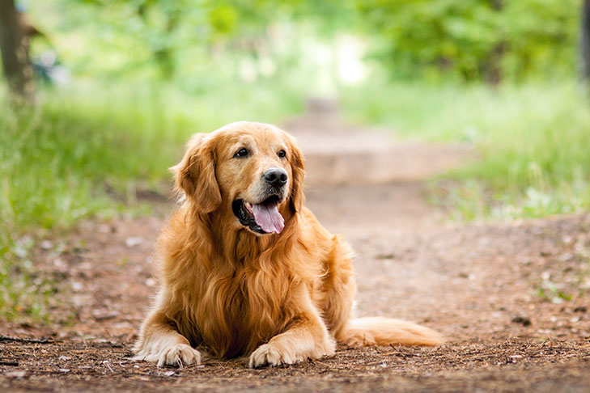

# #5 standard poodle

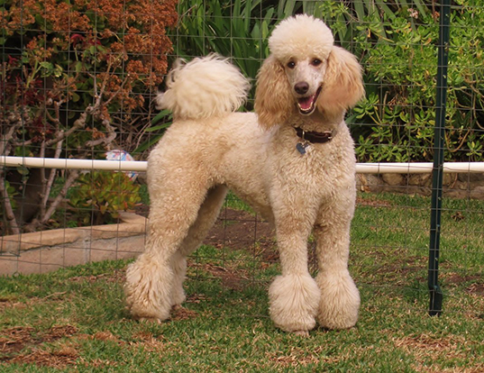

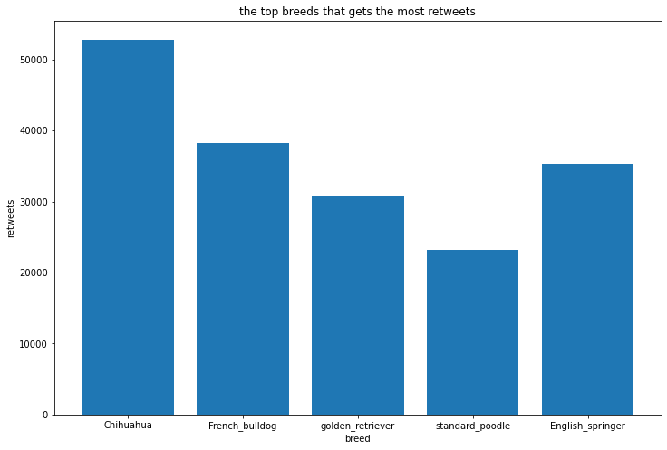

### According to the figure above we can see that people are more likely to retweet when the dog of Chihuahua ,French bulldog, English springer,golden retriever standard poodle breeds

## Another interesting thing is the question,What is the top breeds that gets the most rating?

# #1 pomeranian

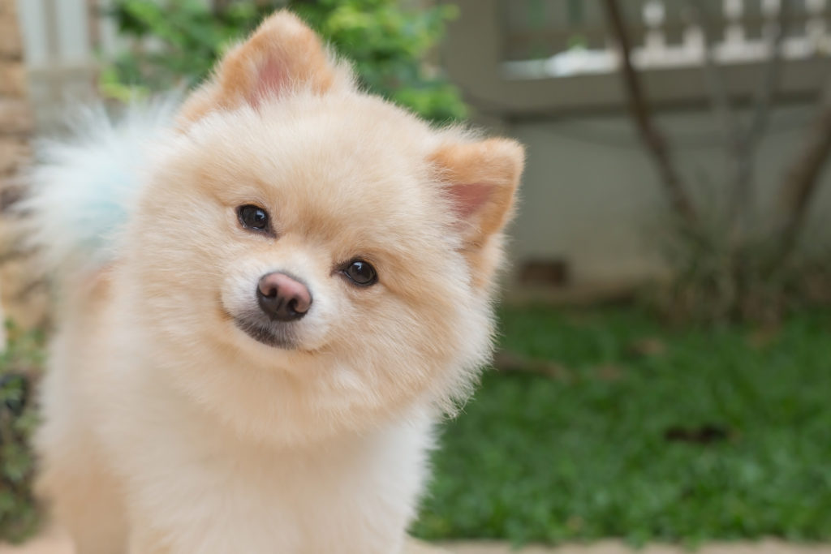

# #2 golden retriever

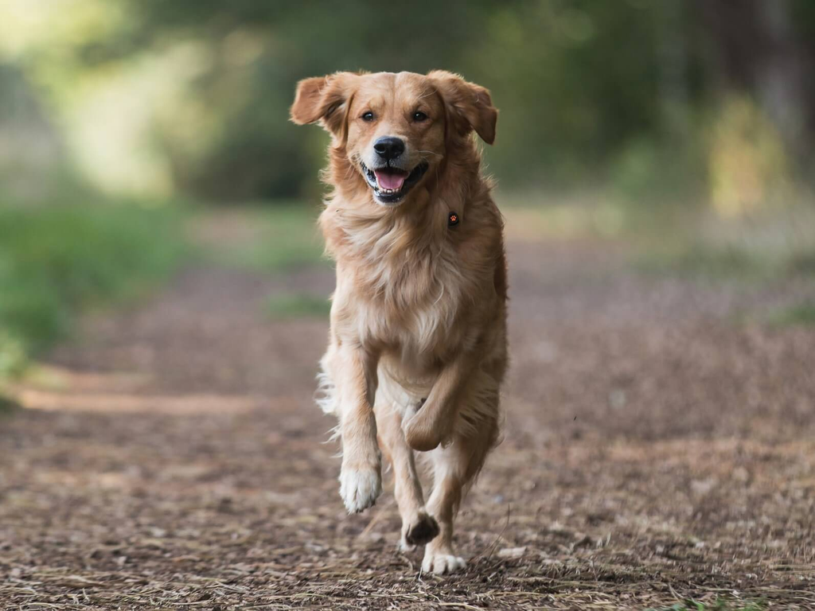